# zadanie4_bagin.R

## vek a vzdelanie

```r
vek_vzdelanie <- dvojfaktorova("vek", "vzdelanie")
```

```
##
##  vek + vzdelanie
##    vzdelanie
## vek  1  2  3  4  5
##   1  9 13 22  7  0
##   2  8 22 34 19 15
##   3  5  8  1  6  0
##   4  4 14 18 10  5
##   5  4  1  6  2  2
##      n  priemer   median       sd rozptyl   minimum  maximum     dolna    horna
## 1.1  9 12763.77 13260.99 1753.755 3075658 10024.071 15320.07 11676.704 13850.83
## 2.1  8 13808.30 13508.78 1775.156 3151180 11012.477 16332.68 12619.242 14997.36
## 3.1  5 12382.91 12531.66 1135.993 1290480 11101.604 13483.22 11299.861 13465.95
## 4.1  4 12438.72 11584.49 2445.016 5978101 10683.755 15902.16  9561.718 15315.73
## 5.1  4 13168.89 14290.66 2622.344 6876688  9278.995 14815.24 10083.226 16254.55
## 1.2 13 13441.80 13383.51 1596.558 2548999 10461.429 15707.65 12652.597 14231.01
## 2.2 22 13622.78 13498.55 1766.539 3120661 10287.497 17047.53 12974.700 14270.86
## 3.2  8 15172.78 15378.81 1706.757 2913018 12551.216 17312.62 14029.533 16316.02
## 4.2 14 13485.70 13866.76 2061.792 4250986  9652.543 16143.55 12509.851 14461.55
## 5.2  1 12991.87 12991.87       NA      NA 12991.871 12991.87        NA       NA
## 1.3 22 14367.84 14539.68 1332.412 1775321 12294.327 17799.96 13879.029 14856.66
## 2.3 34 14316.87 14460.97 2122.221 4503821  9310.645 18581.67 13700.926 14932.82
## 3.3  1 12734.05 12734.05       NA      NA 12734.047 12734.05        NA       NA
## 4.3 18 15271.83 14908.34 2314.636 5357538 11340.492 19380.43 14322.765 16220.90
## 5.3  6 11943.29 12030.30 1640.361 2690783  9463.586 14102.63 10593.867 13292.72
## 1.4  7 14002.50 13887.26 1643.695 2701734 12040.048 16628.35 12795.286 15209.72
## 2.4 19 14460.34 14363.91 1498.095 2244288 12204.789 17229.29 13864.366 15056.31
## 3.4  6 15579.74 16067.81 1577.589 2488788 12841.606 17060.94 14281.955 16877.53
## 4.4 10 14369.83 14391.69 1696.525 2878199 12048.684 16634.17 13386.383 15353.27
## 5.4  2 14950.87 14950.87 1269.759 1612289 14053.019 15848.73  9282.038 20619.71
## 2.5 15 14316.37 14534.99 1549.479 2400886 10888.391 16617.86 13611.714 15021.02
## 4.5  5 14439.75 13947.90 1429.903 2044622 13134.627 16154.45 13076.492 15803.00
## 5.5  2 13640.98 13640.98 1481.133 2193756 12593.657 14688.30  7028.462 20253.49
##     p_shapiro skupina
## 1.1 0.7502945     1.1
## 2.1 0.3649895     2.1
## 3.1 0.2061529     3.1
## 4.1 0.1752698     4.1
## 5.1 0.0367398     5.1
## 1.2 0.8575577     1.2
```

[output cut: 50 more lines]

```
## <none>                 756454708 3539.4
## vek        4  27969678 784424386 3539.9  2.0891 0.083118 .
## vzdelanie  4  57307962 813762671 3548.5  4.2804 0.002336 **
## ---
## Signif. codes:  0 '***' 0.001 '**' 0.01 '*' 0.05 '.' 0.1 ' ' 1
##      faktor parcialne_eta2
## 1       vek     0.03565631
## 2 vzdelanie     0.07042343
##        R2
## 0.1019298
##
##  Shapiro-Wilk normality test
##
## data:  residuals(aditivny)
## W = 0.9964, p-value = 0.8673
```

```
## Coefficient covariances computed by hccm()
```

```
## Analysis of Deviance Table (Type II tests)
##
## Response: prijem
##            Df      F   Pr(>F)
## vek         4 1.7407 0.141939
## vzdelanie   4 3.8971 0.004418 **
## Residuals 226
## ---
## Signif. codes:  0 '***' 0.001 '**' 0.01 '*' 0.05 '.' 0.1 ' ' 1
```

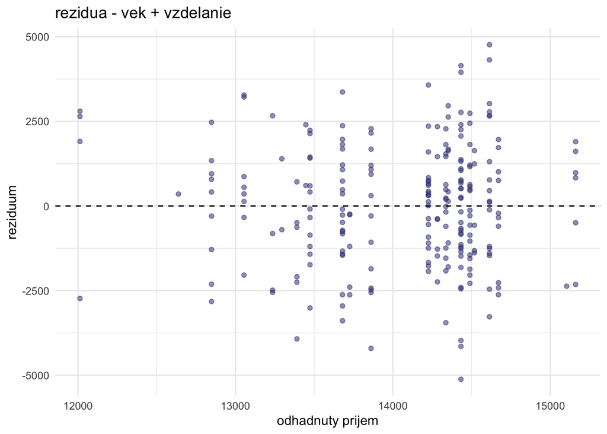

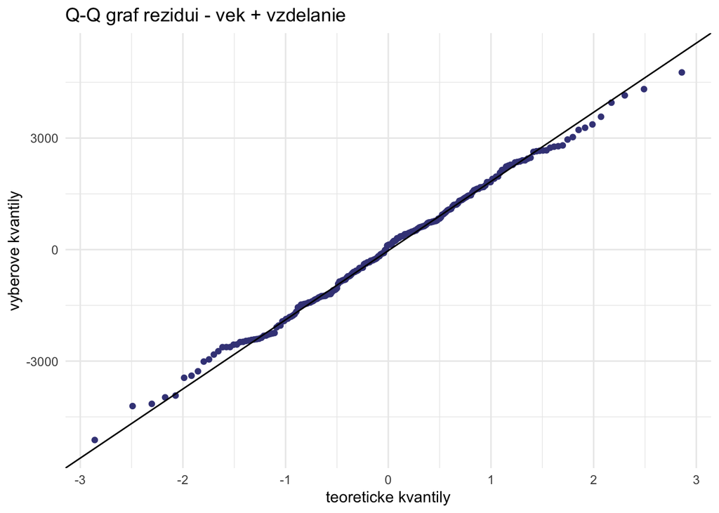

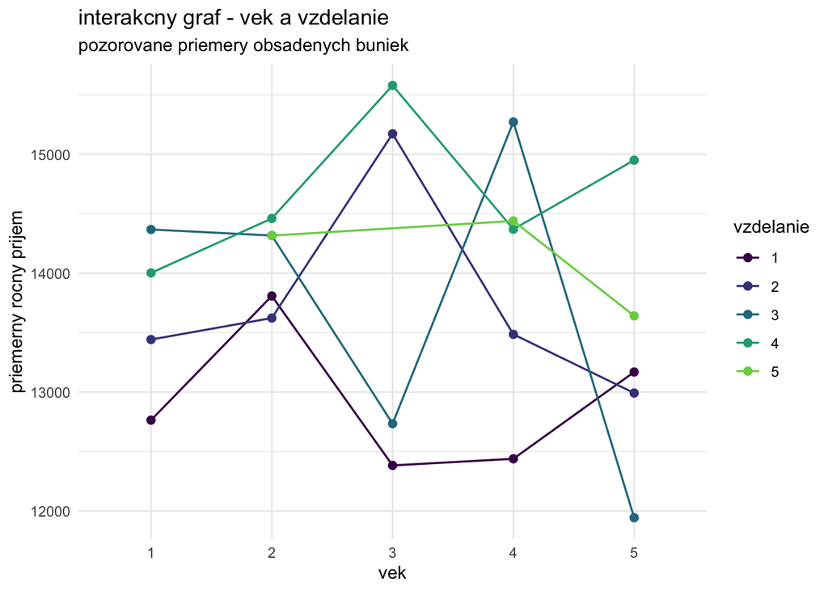

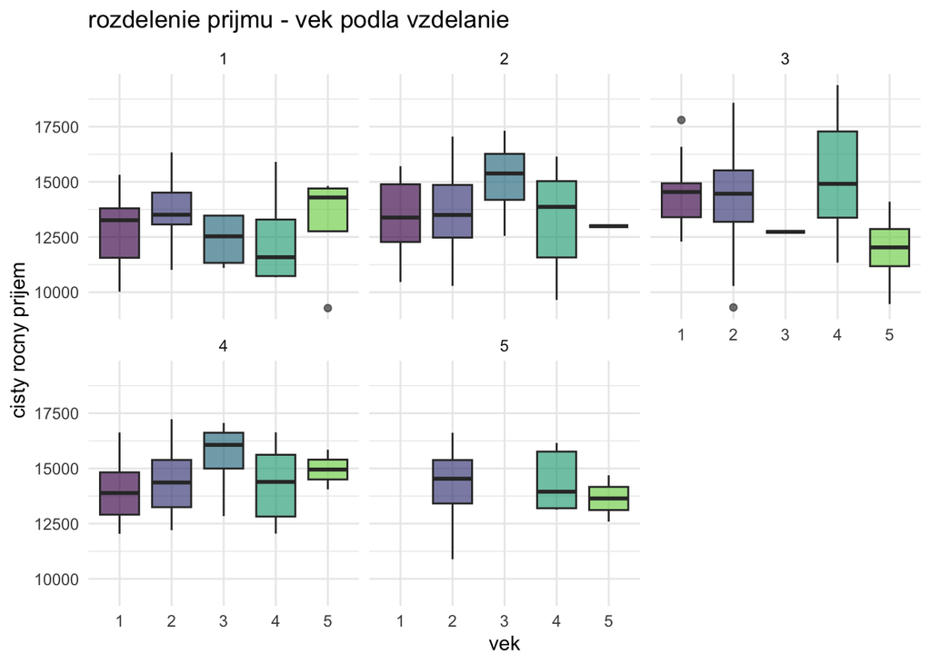

```
##
## upravene priemery a post hoc testy: vek
##   skupina  priemer    dolna    horna
## 1       1 13791.89 13340.17 14243.61
## 2       2 13998.46 13680.52 14316.39
## 3       3 14669.98 13972.31 15367.65
## 4       4 14179.88 13742.14 14617.62
## 5       5 12956.36 12168.58 13744.14
##    dvojica    rozdiel       se          t  df       dolna      horna
## 1      2-1   206.5639 324.4541  0.6366507 226  -329.31222  742.44005
## 2      3-1   878.0883 493.2868  1.7800767 226    63.36409 1692.81259
## 3      4-1   387.9910 366.7647  1.0578742 226  -217.76641  993.74832
## 4      5-1  -835.5311 542.8207 -1.5392395 226 -1732.06672   61.00458
## 5      3-2   671.5244 464.2072  1.4466048 226   -95.17133 1438.22018
## 6      4-2   181.4270 316.8984  0.5725085 226  -341.96992  704.82399
## 7      5-2 -1042.0950 513.0428 -2.0312049 226 -1889.44864 -194.74133
## 8      4-3  -490.0974 493.9304 -0.9922398 226 -1305.88457  325.68979
## 9      5-3 -1713.6194 638.5499 -2.6836109 226 -2768.26361 -658.97521
## 10     5-4 -1223.5220 544.0572 -2.2488848 226 -2122.09990 -324.94414
##              p     p_holm vyznamny
## 1  0.524996728 1.00000000    FALSE
## 2  0.076406961 0.53484873    FALSE
## 3  0.291242187 1.00000000    FALSE
## 4  0.125144772 0.75086863    FALSE
## 5  0.149393140 0.75086863    FALSE
## 6  0.567546601 1.00000000    FALSE
## 7  0.043404854 0.34723883    FALSE
## 8  0.322141696 1.00000000    FALSE
## 9  0.007822024 0.07822024     TRUE
## 10 0.025484025 0.22935623    FALSE
```

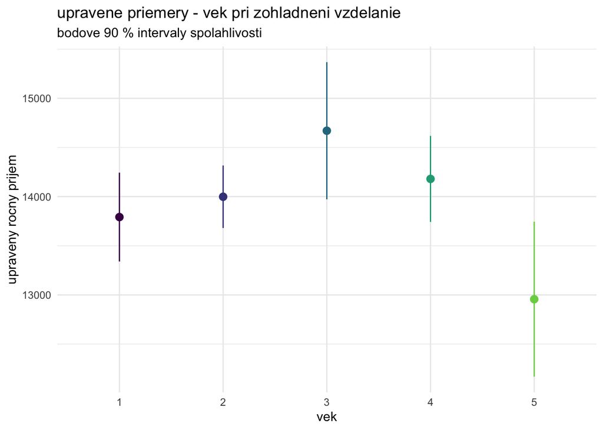

```
##
## upravene priemery a post hoc testy: vzdelanie
##   skupina  priemer    dolna    horna
## 1       1 12975.17 12417.83 13532.52
## 2       2 13600.75 13172.27 14029.23
## 3       3 14353.12 13971.92 14734.31
## 4       4 14410.16 13930.45 14889.86
## 5       5 14257.37 13569.50 14945.24
##    dvojica    rozdiel       se          t  df     dolna     horna           p
## 1      2-1  625.57680 417.3546  1.4989094 226  -63.7361 1314.8897 0.135292664
## 2      3-1 1377.94167 399.2722  3.4511332 226  718.4941 2037.3892 0.000666095
## 3      4-1 1434.98447 438.8375  3.2699677 226  710.1900 2159.7790 0.001243582
## 4      5-1 1282.19746 531.4558  2.4126135 226  404.4324 2159.9625 0.016636356
## 5      3-2  752.36487 320.6570  2.3463232 226  222.7602 1281.9696 0.019824837
## 6      4-2  809.40766 366.5591  2.2081234 226  203.9900 1414.8254 0.028240660
## 7      5-2  656.62066 470.5714  1.3953690 226 -120.5862 1433.8275 0.164274179
## 8      4-3   57.04280 348.0800  0.1638784 226 -517.8545  631.9401 0.869973338
## 9      5-3  -95.74421 448.5001 -0.2134764 226 -836.4977  645.0093 0.831147821
## 10     5-4 -152.78701 485.9379 -0.3144167 226 -955.3737  649.7997 0.753494626
##        p_holm vyznamny
## 1  0.67646332    FALSE
## 2  0.00666095     TRUE
## 3  0.01119224     TRUE
## 4  0.13309085    FALSE
## 5  0.13877386    FALSE
## 6  0.16944396    FALSE
## 7  0.67646332    FALSE
## 8  1.00000000    FALSE
## 9  1.00000000    FALSE
## 10 1.00000000    FALSE
```

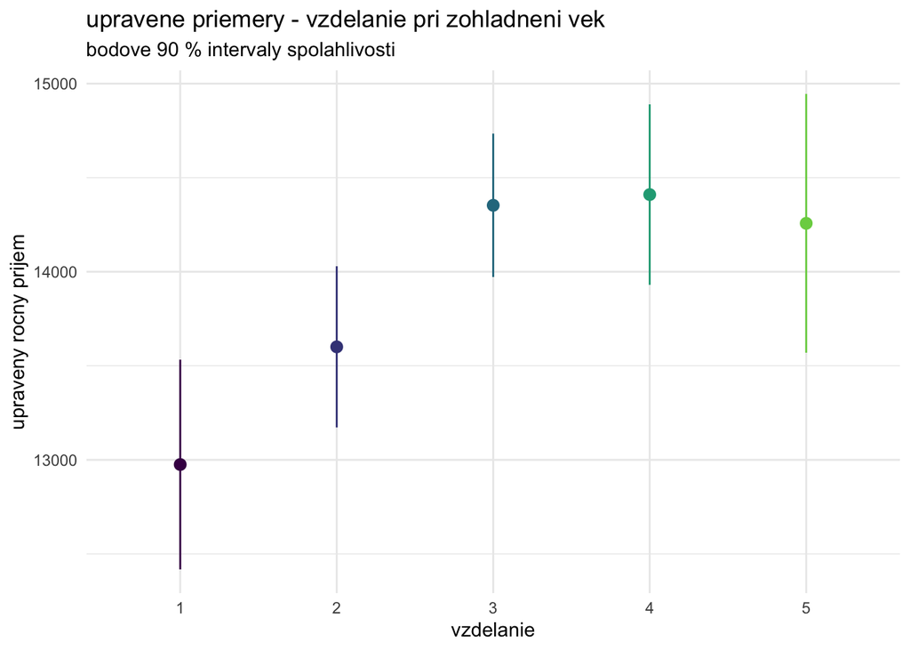

Pri $\alpha = 0,10$ sa interakcia nepreukazala ($p = 0,1633$), ale vek ($p = 0,08312$) aj vzdelanie ($p = 0,002336$) su v klasickom modeli vyznamne. Holmova korekcia potvrdila nizsi prijem vekovej skupiny 56+ oproti 36 az 45 rokom a vyssi prijem vzdelanostnych skupin 3 a 4 oproti skupine 1. Prazdne a male bunky obmedzuju analyzu, HC3 potvrdzuje iba vzdelanie, preto vyznamnost veku nie je robustna.

# 4. dieta - percentualna strata hmotnosti

$strata\,(\%) = 100 \times \frac{hmotnost_{pred} - hmotnost_{po}}{hmotnost_{pred}}$. 100 % je vlastna povodna hmotnost kazdeho klienta. Pocitame individualne percenta, nie percento z priemerov. kladna strata znamena schudnutie a zaporna strata pribratie. Tieto hodnoty automaticky nevyradujeme.

```r
dieta$strata_percent <- 100 * (dieta$pred - dieta$po) / dieta$pred
table(dieta$pohlavie)
```

```
##
## zeny muzi
##  103   99
```

```r
table(dieta$pohlavie, pribratie = dieta$strata_percent < 0)
```

```
##       pribratie
##        FALSE TRUE
##   zeny    83   20
##   muzi    80   19
```

```r
popis_diety <- popis_skupin(dieta$strata_percent, dieta$pohlavie)


popis_diety
```

```
##        n  priemer    median       sd  rozptyl   minimum  maximum    dolna
## zeny 103 9.528353  9.467456 9.972643 99.45360 -17.90503 32.86068 7.579303
## muzi  99 9.101233 10.795331 9.489528 90.05115 -15.97235 29.55140 7.208580
##         horna   p_shapiro skupina
## zeny 11.47740 0.754962212    zeny
## muzi 10.99389 0.008866094    muzi
```

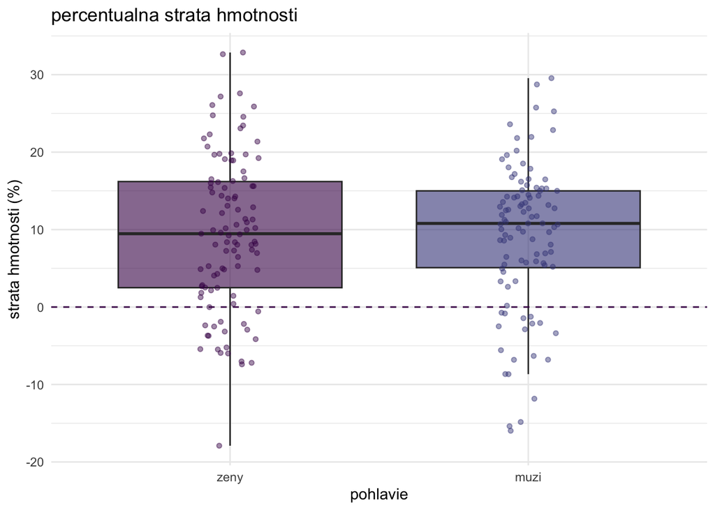

```r
print(graf_skupin(dieta, "strata_percent", "pohlavie", "percentualna strata hmotnosti", "strata hmotnosti (%)") +
        geom_hline(yintercept = 0, linetype = 2, color = farby[1]))
```

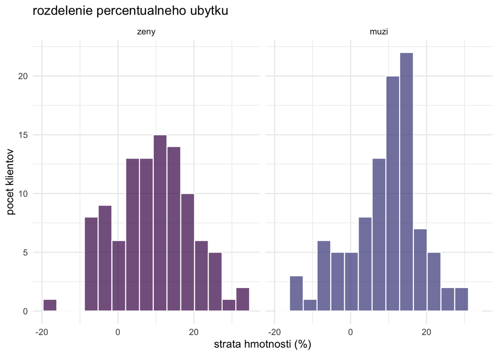

```r
print(ggplot(dieta, aes(strata_percent, fill = pohlavie)) +
        geom_histogram(bins = 15, color = "white", alpha = 0.7) + facet_wrap(~ pohlavie) +
        scale_fill_manual(values = farby, guide = "none") + theme_minimal() +
        labs(title = "rozdelenie percentualneho ubytku", x = "strata hmotnosti (%)", y = "pocet klientov"))
```

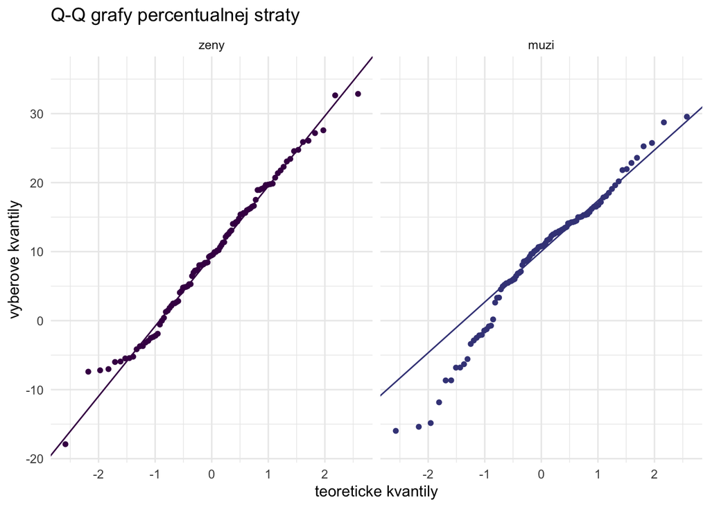

```r
print(graf_normality(dieta, "strata_percent", "pohlavie", "Q-Q grafy percentualnej straty"))
```

Priemerna strata hmotnosti bola 9,52835 % u zien a 9,10123 % u muzov. Pribralo 20 zien a 19 muzov, tieto vecne mozne hodnoty ponechavame v analyze. Zadanie predpoklada normalitu, no Shapirov test ju u muzov zamieta ($p = 0,008866$), preto vysledky t-testov hodnotime s touto vyhradou.

## rozdiel percentualnej straty medzi muzmi a zenami

$H_0: \mu_{zeny} = \mu_{muzi}$, $H_1: \mu_{zeny} \neq \mu_{muzi}$, $\alpha = 0,05$. ide o dva nezavisle vybery klientov. Pred/po u tej istej osoby zostava sparovane pri vypocte percenta. medzi pohlaviami nepouzivame parovy t-test ani neporovnavame samotne konecne hmotnosti.

```r
test_rozptylov_dieta <- var.test(strata_percent ~ pohlavie, data = dieta)
test_rozptylov_dieta
```

```
##
##  F test to compare two variances
##
## data:  strata_percent by pohlavie
## F = 1.1044, num df = 102, denom df = 98, p-value = 0.6216
## alternative hypothesis: true ratio of variances is not equal to 1
## 95 percent confidence interval:
##  0.7439436 1.6369640
## sample estimates:
## ratio of variances
##           1.104412
```

F-test rozptylov: $F = 1,10441$, $p = 0,6216$, rovnost rozptylov nezamietame. napriek tomu volime Welchov t-test, ktory rovnost rozptylov nepotrebuje.

```r
test_pohlavie <- stats::t.test(strata_percent ~ pohlavie, data = dieta,
                              var.equal = FALSE, alternative = "two.sided", conf.level = 1 - alfa)
test_pohlavie
```

```
##
##  Welch Two Sample t-test
##
## data:  strata_percent by pohlavie
## t = 0.31191, df = 199.98, p-value = 0.7554
## alternative hypothesis: true difference in means between group zeny and group muzi is not equal to 0
## 95 percent confidence interval:
##  -2.273140  3.127378
## sample estimates:
## mean in group zeny mean in group muzi
##           9.528353           9.101233
```

```r
rozdiel_pohlavie <- mean(dieta$strata_percent[dieta$pohlavie == "zeny"]) -
  mean(dieta$strata_percent[dieta$pohlavie == "muzi"])
rozdiel_pohlavie
```

```
## [1] 0.4271193
```

Welchov t-test ($p = 0,75543$) nezamieta $H_0$, rozdiel priemernej percentualnej straty medzi pohlaviami sa nepreukazal. Zeny stratili priemerne o 0,42712 percentualneho bodu viac, 95 % interval rozdielu od -2,27314 do 3,12738 vsak obsahuje nulu. Nezamietnutie $H_0$ nie je dokaz rovnakej ucinnosti programu pre obe pohlavia.

## predpoklad poradkyne pre zeny

$H_0: \mu_{zeny} = 13\,\%$, $H_1: \mu_{zeny} \neq 13\,\%$, $\alpha = 0,05$. overujeme konkretny predpoklad, preto pouzijeme obojstranny jednovyberovy t-test.

```r
zeny <- dieta$strata_percent[dieta$pohlavie == "zeny"]
test_zeny <- stats::t.test(zeny, mu = 13, alternative = "two.sided", conf.level = 1 - alfa)
test_zeny
```

```
##
##  One Sample t-test
##
## data:  zeny
## t = -3.533, df = 102, p-value = 0.0006188
## alternative hypothesis: true mean is not equal to 13
## 95 percent confidence interval:
##   7.579303 11.477402
## sample estimates:
## mean of x
##  9.528353
```

```r
c(rozdiel_od_predpokladu = mean(zeny) - 13)
```

```
## rozdiel_od_predpokladu
##              -3.471647
```

Jednovyberovy t-test ($p = 0,0006188$) zamieta $H_0$, priemerna strata zien je nizsia nez predpokladanych 13 %. Dosiahnuty priemer je 9,52835 % a jeho 95 % interval od 7,57930 % do 11,47740 % neobsahuje 13 %. Predpoklad poradkyne pre zeny data nepodporuju, samostatny test tvrdenia o muzoch zadanie nepozaduje.

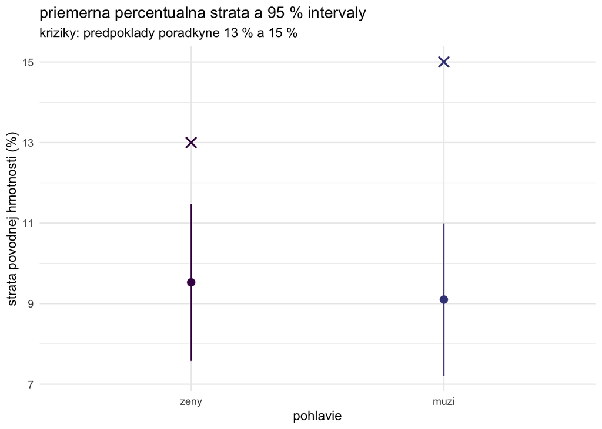

```r
popis_diety$predpoklad <- c(13, 15)[match(as.character(popis_diety$skupina), c("zeny", "muzi"))]
print(ggplot(popis_diety, aes(skupina, priemer, ymin = dolna, ymax = horna, color = skupina)) +
        geom_pointrange() + geom_point(aes(y = predpoklad), shape = 4, size = 3, stroke = 1.1) +
        scale_color_manual(values = farby, guide = "none") + theme_minimal() +
        labs(title = "priemerna percentualna strata a 95 % intervaly",
             subtitle = "kriziky: predpoklady poradkyne 13 % a 15 %",
             x = "pohlavie", y = "strata povodnej hmotnosti (%)"))
```

# zaver

Prijem sa pri $\alpha = 0,05$ lisi podla vzdelania a miesta prace, rozdiel podla veku a sektora sa nepreukazal. Dvojfaktorove modely nepreukazali interakcie a vyznamnost veku je citliva na pouzitu metodu a obmedzenia dat. Rozdiel percentualnej straty medzi pohlaviami sa nepreukazal, priemerna strata zien je vsak nizsia nez predpokladanych 13 %.